# Statistical Inference

### Course Project - Assignment 2

### Synopsis

This report has been created for the the *Statistical Inference* MOOC from Johns Hopkins university on [Coursera](https://class.coursera.org/statinference-005).

The second assignment required analysis of the ToothGrowth data set in R. Specifically, the following points had to be addressed:

1. Load the ToothGrowth data and perform some basic exploratory data analyses
2. Provide a basic summary of the data.
3. Use confidence intervals and hypothesis tests to compare tooth growth by supp and dose.
4. State your conclusions and the assumptions needed for your conclusions.

See Appendix 1 for the complete, end-to-end R code that generates all the required output.

### Data Processing:

#### Loading and Summarising ToothGrowth Data

The structure of this data is:

```
## 'data.frame':    60 obs. of  3 variables:
##  $ len : num  4.2 11.5 7.3 5.8 6.4 10 11.2 11.2 5.2 7 ...
##  $ supp: Factor w/ 2 levels "OJ","VC": 2 2 2 2 2 2 2 2 2 2 ...
##  $ dose: num  0.5 0.5 0.5 0.5 0.5 0.5 0.5 0.5 0.5 0.5 ...
```

Looking at this output, this analysis has coded the values of the `supp` variable as follows:

- OJ - Orange Juice
- VC - Ascorbic Acid

##### Summarising Data

Given that the `supp` and `dose` variables are values used by the study and not recorded data, it is sufficient to look only at the summary of the `len` data (i.e the tooth length):

```
##    Min. 1st Qu.  Median    Mean 3rd Qu.    Max.
##     4.2    13.1    19.2    18.8    25.3    33.9
```

Additionally, it is calculated that the standard deviation of the tooth length is 7.6493. The 95% confidence interval of the mean ranges from 16.8 to 20.8.

#### Exploring the Data

##### Summarising By supplement

Next, a brief summary is performed by supplement:

```
## Source: local data frame [2 x 5]
##
##            supp mean_growth sd_growth lower_95 upper_95
## 1  Orange Juice       20.66     6.606    18.20    23.13
## 2 Ascorbic Acid       16.96     8.266    13.88    20.05
```

The data presented show the mean growth with orange juice (20.66) and with pure ascorbic acid (16.96) as well as the standard deviation and the 95% confidence intervals for these values.

##### Figure 1 - Mean tooth length by supplement:

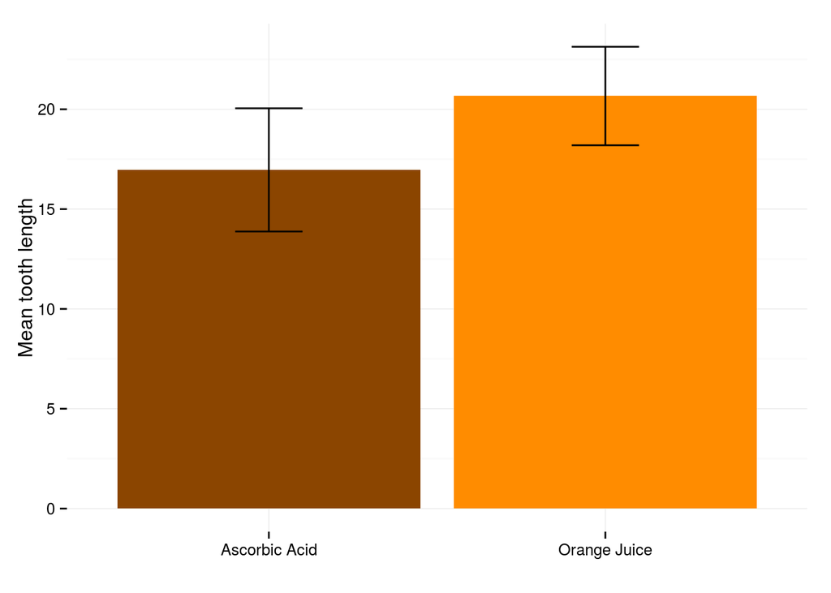

It appears that orange juice results in a larger tooth length than pure ascorbic acid. This is tested below.

##### Summarising By Dose

A brief summary is performed by dose:

```
## Source: local data frame [3 x 5]
##
##   dose mean_growth sd_growth lower_95 upper_95
## 1  0.5       10.61     4.500    8.885    12.32
## 2  1.0       19.73     4.415   18.048    21.42
## 3  2.0       26.10     3.774   24.658    27.54
```

##### Figure 2 - Mean tooth length by dose:

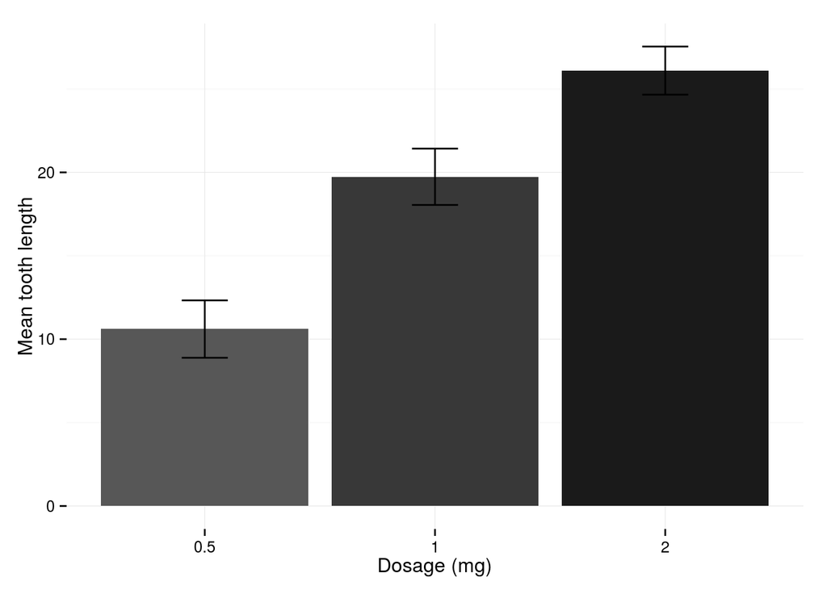

##### Summarising By supplement *and* Dose

A brief summary is performed by supplement *and* dose:

```
## Source: local data frame [6 x 5]
## Groups:
##
##            supp dose mean_growth sd_growth lower_95
## 1  Orange Juice  0.5       13.23     4.460   11.388
## 2  Orange Juice  1.0       22.70     3.911   21.085
## 3  Orange Juice  2.0       26.06     2.655   24.963
## 4 Ascorbic Acid  0.5        7.98     2.747    6.846
## 5 Ascorbic Acid  1.0       16.77     2.515   15.731
## 6 Ascorbic Acid  2.0       26.14     4.798   24.158
```

The data presented show the mean growth for doses of 2.0mg, 1.0mg and 0.5mg of the respective supplements as well as the standard deviation and the 95% confidence intervals for these values.

##### Figure 3 - Mean tooth length by supplement and dose:

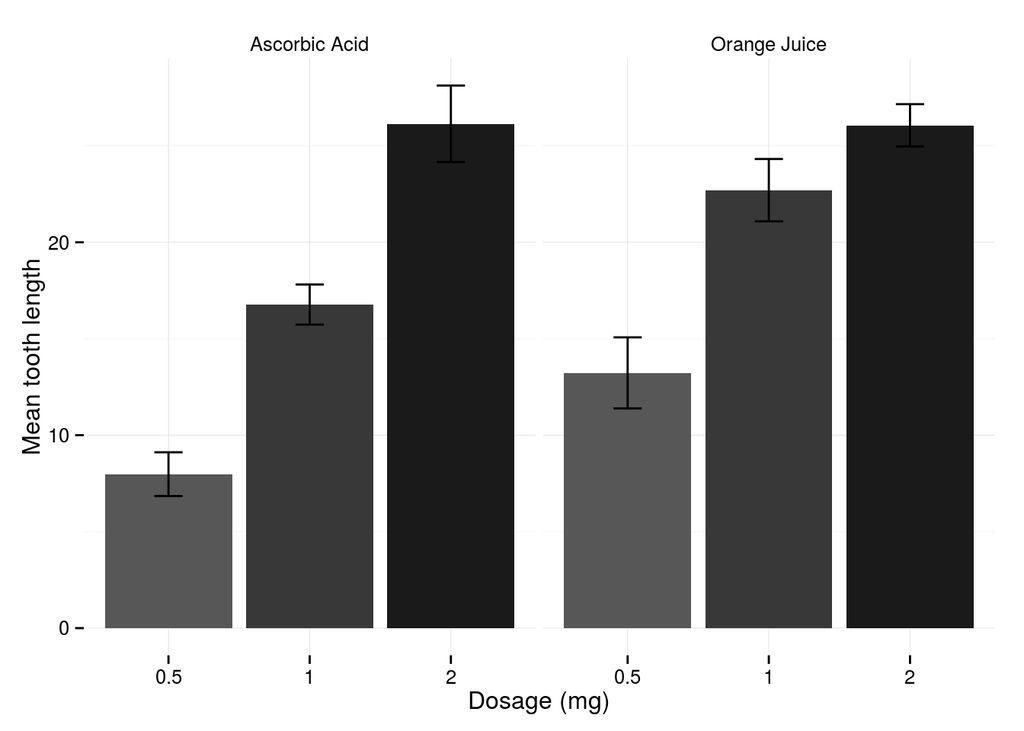

It is interesting to note that whilst orange juice appears to result in a larger mean growth at low and medium does (0.5 and 1.0mg), at a higher dosage of 2.0mg it appears that the two supplements are roughly equivalent.

This is tested below.

### Hypothesis Testing:

Broadly speaking, the exploration of the data has presented two main hypotheses:

1. Orange juice supplementation produces a higher mean tooth growth than ascorbic acid; and
2. A higher dosage of either supplement produces a higher mean tooth growth.

#### Testing Based on supplement

The Student’s $t$-test output for the comparison of tooth growth with orange juice compared to ascorbic acid is:

```
##
##  Two Sample t-test
##
## data:  oj and vc
## t = 1.915, df = 58, p-value = 0.0302
## alternative hypothesis: true difference in means is greater than 0
## 95 percent confidence interval:
##  0.4708    Inf
## sample estimates:
## mean of x mean of y
##     20.66     16.96
```

With a $p$-value of 0.03 and a $t$-confidence interval of 0.4708 to ∞ (i.e. not containing 0) it seems reasonable to reject the null hypothesis, and so the data show that orange juice produces a higher mean tooth growth than ascorbic acid.

#### Testing Based on Dose

##### Comparing 2.0mg with 0.5mg

The Student’s $t$-test output for the comparison of tooth growth with a dose of 2.0mg compared to 0.5mg is:

```
##
##  Two Sample t-test
##
## data:  dose2 and dose0.5
## t = 11.8, df = 38, p-value = 1.419e-14
## alternative hypothesis: true difference in means is greater than 0
## 95 percent confidence interval:
##  13.28   Inf
## sample estimates:
## mean of x mean of y
##     26.10     10.61
```

With a $p$-value of 1.4188 × 10<sup>-14</sup> and a $t$-confidence interval of 13.2809 to ∞ (i.e. not containing 0) it seems reasonable to reject the null hypothesis, and so the data show that 2.0mg of supplement produces a higher mean tooth growth than 0.5mg of supplement.

##### Comparing 2.0mg with 1.0mg

Similarly, the Student’s $t$-test output for the comparison of tooth growth with a dose of 2.0mg compared to 1.0mg is:

```
##
##  Two Sample t-test
##
## data:  dose2 and dose1
## t = 4.901, df = 38, p-value = 1.811e-05
## alternative hypothesis: true difference in means is not equal to 0
## 95 percent confidence interval:
##  3.736 8.994
## sample estimates:
## mean of x mean of y
##     26.10     19.73
```

With a $p$-value of 1.8108 × 10<sup>-5</sup> and a $t$-confidence interval of 3.7356 to 8.9944 (i.e. not containing 0) it seems reasonable to reject the null hypothesis, and so the data show that 2.0mg of supplement also produces a higher mean tooth growth than 1.0mg of supplement.

##### Comparing 1.0mg with 0.5mg

Finally, the Student’s $t$-test output for the comparison of tooth growth with a dose of 1.0mg compared to 0.5mg is:

```
##
##  Two Sample t-test
##
## data:  dose1 and dose0.5
## t = 6.477, df = 38, p-value = 6.331e-08
## alternative hypothesis: true difference in means is greater than 0
## 95 percent confidence interval:
##  6.753   Inf
## sample estimates:
## mean of x mean of y
##     19.73     10.61
```

#### Testing Based on supplement *and* Dose

The previous results show that orange juice produces a higher mean growth than ascorbic acid; and similarly a higher dosage produces a higher mean growth.

Whether these results can be cross-validated, i.e. does orange juice provide a higher growth rate at *all* doses (recall from the exploratory analysis that this only seemed to be the case at low and mediaum doses) is shown below:

##### Comparing Orange Juice to Ascorbic Acid at 0.5mg

The Student’s $t$-test output is:

```
##
##  Two Sample t-test
##
## data:  doseoj.5 and dosevc.5
## t = 3.17, df = 18, p-value = 0.005304
## alternative hypothesis: true difference in means is not equal to 0
## 95 percent confidence interval:
##  1.77 8.73
## sample estimates:
## mean of x mean of y
##     13.23      7.98
```

With a $p$-value of 0.0053 and a $t$-confidence interval of 1.7703 to 8.7297 (i.e. not containing 0) it seems reasonable to reject the null hypothesis, i.e. at low doses there appears to be a statistically significant difference between the two supplements.

##### Comparing Orange Juice to Ascorbic Acid at 1.0mg

The Student’s $t$-test output is:

```
##
##  Two Sample t-test
##
## data:  doseoj1 and dosevc1
## t = 4.033, df = 18, p-value = 0.0007807
## alternative hypothesis: true difference in means is not equal to 0
## 95 percent confidence interval:
##  2.841 9.019
## sample estimates:
## mean of x mean of y
##     22.70     16.77
```

With a $p$-value of 7.8073 × 10<sup>-4</sup> and a $t$-confidence interval of 2.8407 to 9.0193 (i.e. not containing 0) it seems reasonable to reject the null hypothesis, i.e. at medium doses there appears to be a statistically significant difference between the two supplements.

##### Comparing Orange Juice to Ascorbic Acid at 2.0mg

The Student’s $t$-test output is:

```
##
##  Two Sample t-test
##
## data:  doseoj2 and dosevc2
## t = -0.0461, df = 18, p-value = 0.9637
## alternative hypothesis: true difference in means is not equal to 0
## 95 percent confidence interval:
##  -3.723  3.563
## sample estimates:
## mean of x mean of y
##     26.06     26.14
```

With a $p$-value of 0.9637 and a $t$-confidence interval of -3.723 to 3.563 (i.e. *containing* 0) it seems reasonable to *fail* to reject the null hypothesis, i.e. at higher doses there does not appear to be a statistically significant difference between the two supplements.

### Assumptions

All the Student’s $t$-tests in this exercise have been conducted assuming equal variances. As all subjects were guinea pigs, it was assumed that the population was simply *all guinea pigs* and so the *population* variance in tooth size would be equal in each subject group.

Additionally, in order to perform a Students $t$-test, it is assumed that the data are normally distributed. With a sample of only 60 guinea pigs, this is a reasonable assumption to make. However it is imporant to **test this assumption**. This is done by plotting a density distribution of the sample, and overlaying a normal distribution curve:

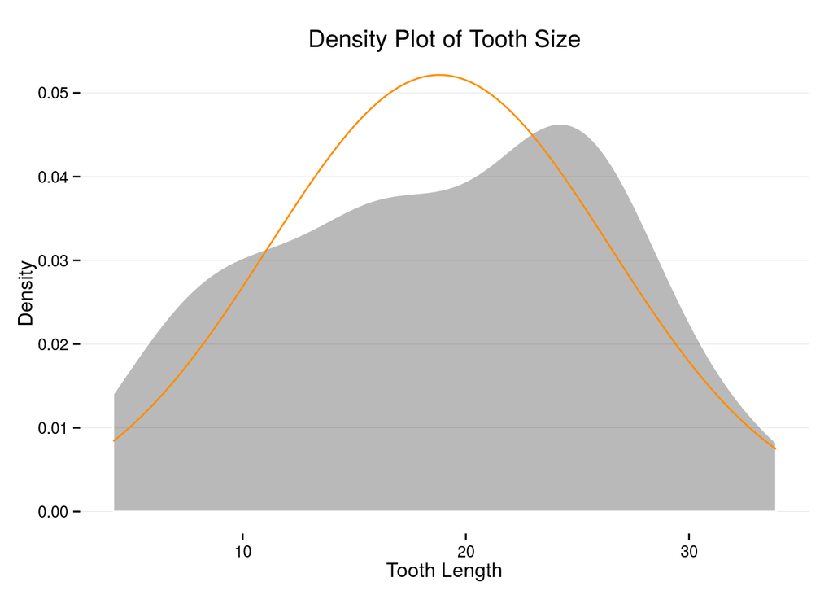

Whilst this plot shows that it is the case that the data deviate *slightly* from the truly normal distribution with a small negative skew, it seems reasonable to maintain this assumption as the deviation is very small.

### Conclusions

Overall, it is possible to conclude that there is a statistically significant difference between both orange juice and ascorbic acid, and the dosage at which these supplements are applied.

Generally speaking a higher dosage results in a larger tooth growth and similarly orange juice results in a larger growth than pure ascorbic acid.

However, whilst this is true intra-supplement and medium and low does, at high doses, the two suppliments appear to produce approximately the same growth, with no statistically significant difference between the two.

### References and Contact

A number of packages were used and are therefore required for this analysis. These packages were:

- [magrittr](http://cran.r-project.org/web/packages/magrittr/vignettes/magrittr.html)
- [ggplot2](http://ggplot2.org/)
- [dplyr](http://blog.rstudio.org/2014/01/17/introducing-dplyr/)

The complete code and documentation for this assignment can be found on [GitHub](https://github.com/Jim89/stat_infer) repository.

The author of this report can be contacted on [twitter](https://twitter.com/leach_jim)

### Appendix 1 - Complete R Code

```
################################################################################
# Assignment 2 - Analysis of ToothGrowth data set
################################################################################
# Load ToothGrowth data and perform basic exploratory analysis
# basic summary of data
# confidence intervals and hypothesis tests to compare growth by supp and dose
# state conclusions and assumptions

################################################################################
# Step 0  - load packages
################################################################################
library(ggplot2,quietly=T)
library(magrittr,quietly=T)
library(dplyr,quietly=T)

################################################################################
# Step 1  - load data and perform some brief summaries
################################################################################
data(ToothGrowth)
data <- ToothGrowth

summary(data$len)
sd_len <- sd(data$len)

################################################################################
# Step 2  - explore based on suppliment
################################################################################
# descriptive stats per suppliment
data_sum_sup <- data %>%
  group_by(supp) %>%
  summarise(mean_growth = mean(len),
            sd_growth = sd(len),
            lower_95 = mean_growth - qt(0.975, 29) *
              (sd_growth/sqrt(30)),
            upper_95 = mean_growth + qt(0.975, 29) *
              (sd_growth/sqrt(30)),
            ci = upper_95 - mean_growth)

data_sum_sup$supp <- ifelse(data_sum_sup$supp == "OJ", "Orange Juice",
                            "Ascorbic Acid")
```

[output cut: 113 more lines]

```
# Step 8  - test assumptions - data normally distributed
################################################################################
data %>%
  ggplot(aes(x = len))+
  geom_density(fill = "gray10", alpha = 0.3, color= "white")+
  theme_minimal()+
  xlab("Tooth Length")+
  ylab("Density")+
  ggtitle("Density Plot of Tooth Size")+
  theme(panel.grid.minor.y=element_blank(),
        panel.grid.major.x=element_blank(),
        panel.grid.minor.x=element_blank())+
  stat_function(color="darkorange",
                fun= dnorm,
                args = list(mean = mean(data$len), sd = sd(data$len)))
```